# daa

Maria

15 05 2022

Firstly, training and testing data was loaded. Columns with NA values were discarded for both datasets, leaving 58 explanatory variables for classe factor. Secondly, training dataset was divided with p=0.7 to training and validation dataset. Secondly, random forest with accuracy metric as method evaluation was run, as it is well known method for data classification problems, with great performance and predictive quality. What is more, crossvalidation was performed with 5 folds. For each tree in random forest 8 best variables were chosen to be selected (tuning parameter). Nevertheless, parallel method was executed for improvement of calculation speed. Furthermore, number of trees was defined to be tested between 100, 150, 200, 500.

```r
print(summary(results))
```

```
##
## Call:
## summary.resamples(object = results)
##
## Models: 100, 150, 200, 500
## Number of resamples: 5
##
## Accuracy
##          Min.   1st Qu.    Median      Mean   3rd Qu.      Max. NA's
## 100 0.9967225 0.9967249 0.9981798 0.9979616 0.9989087 0.9992719    0
## 150 0.9970867 0.9970888 0.9981798 0.9980344 0.9985449 0.9992719    0
## 200 0.9970867 0.9974518 0.9974527 0.9980344 0.9989087 0.9992719    0
## 500 0.9970867 0.9974518 0.9974527 0.9979615 0.9989079 0.9989087    0
##
## Kappa
##          Min.   1st Qu.    Median      Mean   3rd Qu.      Max. NA's
## 100 0.9958544 0.9958574 0.9976978 0.9974217 0.9986196 0.9990791    0
## 150 0.9963149 0.9963177 0.9976978 0.9975138 0.9981595 0.9990791    0
## 200 0.9963149 0.9967769 0.9967780 0.9975137 0.9986196 0.9990791    0
## 500 0.9963151 0.9967769 0.9967780 0.9974216 0.9986186 0.9986196    0
```

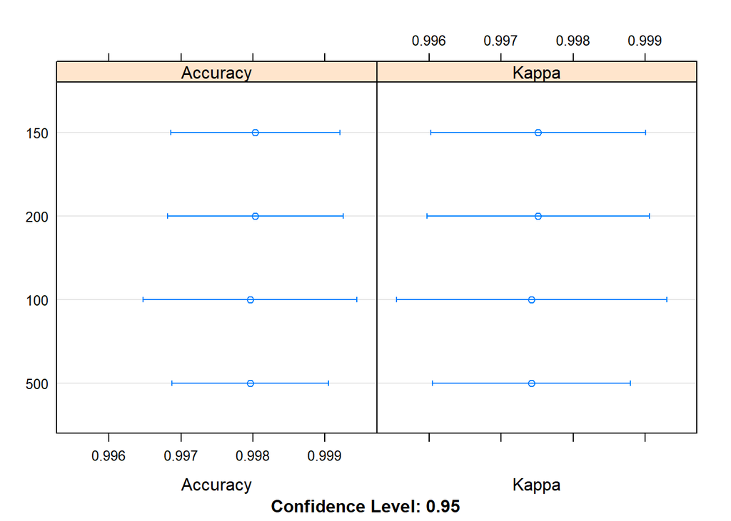

```r
print(dotplot(results))
```

```r
print(confusionMatrix(val_predict, var$classe))
```

```
## Confusion Matrix and Statistics
##
##           Reference
## Prediction    A    B    C    D    E
##          A 1674    1    0    0    0
##          B    0 1138    1    0    0
##          C    0    0 1024    2    0
##          D    0    0    1  962    0
##          E    0    0    0    0 1082
##
## Overall Statistics
##
##                Accuracy : 0.9992
##                  95% CI : (0.998, 0.9997)
##     No Information Rate : 0.2845
##     P-Value [Acc > NIR] : < 2.2e-16
##
##                   Kappa : 0.9989
##
##  Mcnemar's Test P-Value : NA
##
## Statistics by Class:
##
##                      Class: A Class: B Class: C Class: D Class: E
## Sensitivity            1.0000   0.9991   0.9981   0.9979   1.0000
## Specificity            0.9998   0.9998   0.9996   0.9998   1.0000
## Pos Pred Value         0.9994   0.9991   0.9981   0.9990   1.0000
## Neg Pred Value         1.0000   0.9998   0.9996   0.9996   1.0000
## Prevalence             0.2845   0.1935   0.1743   0.1638   0.1839
## Detection Rate         0.2845   0.1934   0.1740   0.1635   0.1839
## Detection Prevalence   0.2846   0.1935   0.1743   0.1636   0.1839
## Balanced Accuracy      0.9999   0.9995   0.9988   0.9989   1.0000
```

For validation dataset random tree with 8 estimators for each decision tree, 500 trees in total resulted in 0.9992 accuracy score. Therefore, for test dataset - predicted 0.99 accuracy score.